# DPWH Budget Analysis

Office of the Secretary — Long-Run Appropriations

AJ Montesa / People’s Budget Coalition

02 June 2026

# 1 Overview

This first section profiles the long-run budget of the **DPWH Office of the Secretary**: a (still incomplete) time series of the **NEP**, **GAA**, and **Actual Obligations** running back to 1988. Three views are shown — the **nominal** trend, the department’s **share of the national budget**, and the **real (inflation-adjusted)** trend in constant 2018 prices.

All figures throughout this document are drawn from the National Expenditure Program (NEP), General Appropriations Act (GAA), and related budget documents published by the Department of Budget and Management (DBM).

A few conventions:

- Amounts are reported in **thousand pesos**; everything below is rescaled to **PHP billions** (`/ 1e6`).
- The headline series is **New + Automatic Appropriations** (the full agency budget, including automatic items). This is also the numerator used for the share of the national budget.
- Points mark **years with observed data**; the connecting line is interpolated, so visible gaps flag where encoding is still pending.

# 2 Nominal Trend

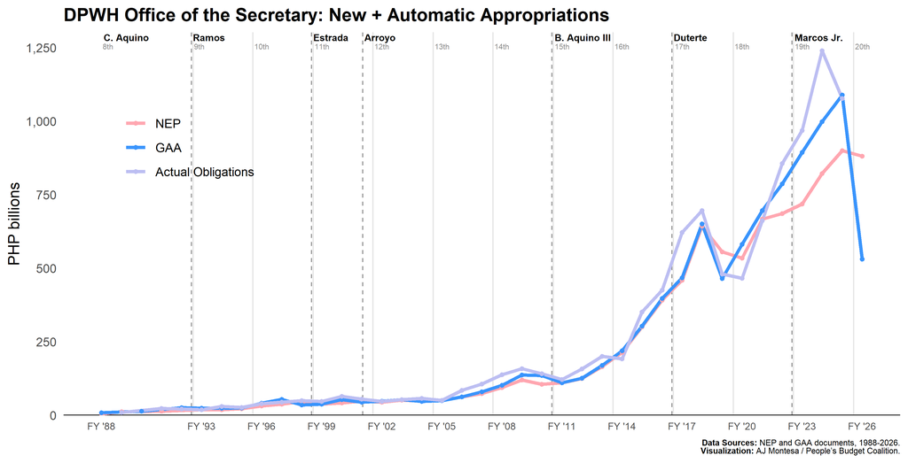

In nominal terms the DPWH OSec budget climbs steeply from the mid-2010s. Two deviations from the usual NEP-to-GAA pattern stand out and are worth raising in hearings: the **2019 GAA fell below the NEP** (the budget-reenactment episode), and the **2026 GAA drops sharply below its NEP** — the reverse of the usual upward realignment seen in most other years.

# 3 Share of the National Budget

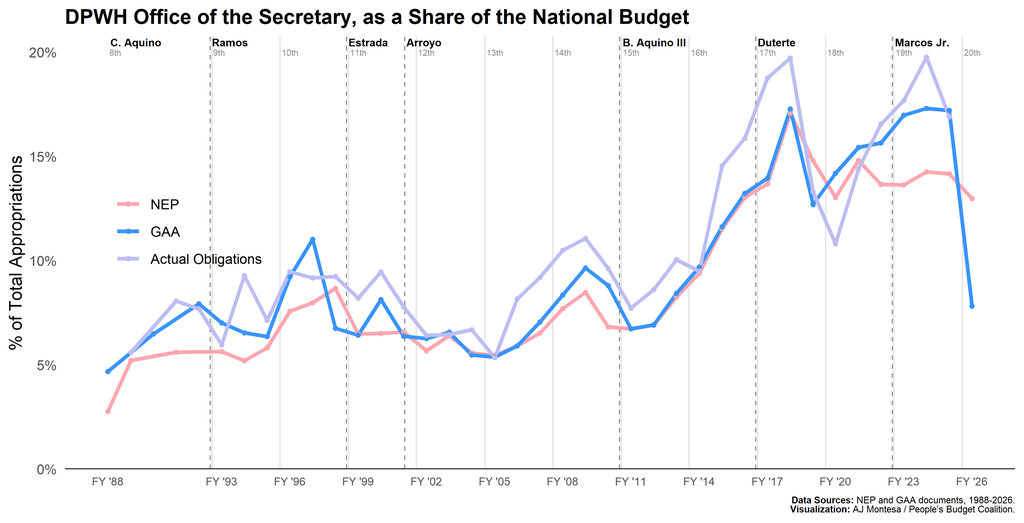

The share view rescales the same money against the size of the whole budget. The department’s footprint roughly **doubles from ~6-8% (1990s-2000s) to a mid-teens share** in the latest years — evidence that DPWH’s expansion outpaced overall budget growth, not merely tracked it. The 2026 NEP-to-GAA gap reappears here as a one-year contraction in the GAA share.

# 4 Real Trend (Inflation-Adjusted)

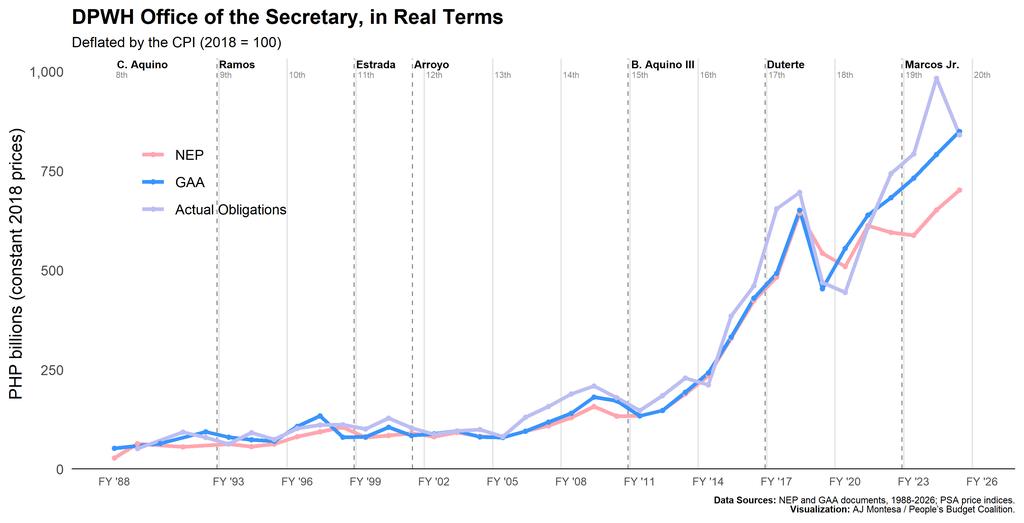

# 5 Summary Table

DPWH Office of the Secretary, New + Automatic Appropriations (PHP billions unless noted)

| FY | NEP | GAA | Actual Oblig. | Realignment (GAA-NEP) | DPWH Share (GAA) | GAA, real 2018 |
| --- | --- | --- | --- | --- | --- | --- |
| 2026 | 881.3 | 530.9 | – | -350.4 | 7.8% | – |
| 2025 | 900.0 | 1,088.8 | 1,077.2 | 188.8 | 17.2% | 849.4 |
| 2024 | 822.2 | 997.9 | 1,239.7 | 175.7 | 17.3% | 791.3 |
| 2023 | 718.4 | 894.2 | 967.9 | 175.8 | 17.0% | 731.9 |
| 2022 | 686.1 | 786.6 | 856.5 | 100.5 | 15.7% | 682.3 |
| 2021 | 667.3 | 695.7 | 662.2 | 28.3 | 15.4% | 638.6 |
| 2020 | 534.3 | 581.7 | 466.1 | 47.4 | 14.2% | 554.9 |
| 2019 | 555.7 | 464.6 | 480.5 | -91.1 | 12.7% | 453.8 |
| 2018 | 643.3 | 650.9 | 696.3 | 7.6 | 17.3% | 650.9 |
| 2017 | 458.6 | 467.7 | 621.9 | 9.1 | 14.0% | 492.2 |
| 2016 | 391.2 | 397.1 | 425.8 | 5.9 | 13.2% | 429.9 |
| 2015 | 300.5 | 303.2 | 351.3 | 2.6 | 11.6% | 332.3 |
| 2014 | 213.0 | 219.3 | 191.8 | 6.4 | 9.7% | 242.0 |
| 2013 | 165.6 | 169.3 | 200.6 | 3.8 | 8.4% | 193.6 |
| 2012 | 125.5 | 125.7 | 157.6 | 0.2 | 6.9% | 147.5 |
| 2011 | 110.6 | 110.6 | 122.0 | 0.0 | 6.7% | 133.8 |
| 2010 | 105.3 | 135.6 | 141.8 | 30.3 | 8.8% | 171.8 |
| 2009 | 120.0 | 137.5 | 158.8 | 17.5 | 9.6% | 180.8 |
| 2008 | 94.5 | 102.4 | 137.9 | 8.0 | 8.3% | 140.4 |
| 2007 | 73.6 | 79.5 | 106.3 | 5.9 | 7.1% | 117.9 |
| 2006 | 62.3 | 62.3 | 85.3 | 0.0 | 5.9% | 95.1 |
| 2005 | 49.5 | 49.5 | 50.7 | 0.0 | 5.4% | 79.6 |
| 2004 | 48.2 | 47.2 | 57.9 | -1.0 | 5.5% | 81.0 |
| 2003 | 51.5 | 53.2 | 53.3 | 1.7 | 6.6% | 95.7 |
| 2002 | 44.3 | 48.3 | 47.6 | 3.9 | 6.3% | 88.8 |
| 2001 | 47.7 | 44.6 | 55.1 | -3.1 | 6.4% | 84.2 |
| 2000 | 42.4 | 52.9 | 64.5 | 10.5 | 8.1% | 105.3 |
| 1999 | 37.6 | 38.1 | 47.6 | 0.5 | 6.4% | 80.9 |
| 1998 | 46.8 | 35.7 | 49.7 | -11.1 | 6.8% | 80.4 |
| 1997 | 38.0 | 54.4 | 45.1 | 16.4 | 11.0% | 134.0 |
| 1996 | 31.5 | 41.1 | 39.4 | 9.7 | 9.2% | 107.1 |
| 1995 | 22.4 | 25.0 | 26.6 | 2.6 | 6.4% | 70.4 |
| 1994 | 18.8 | 24.4 | 30.4 | 5.6 | 6.5% | 73.5 |
| 1993 | 18.6 | 23.8 | 18.7 | 5.2 | 7.0% | 80.6 |
| 1992 | – | 26.0 | 22.0 | – | 7.9% | 94.1 |
| 1991 | 14.3 | – | 23.7 | – | – | – |
| 1990 | – | 13.7 | – | – | 6.5% | 64.3 |
| 1989 | 12.0 | – | 9.7 | – | – | – |
| 1988 | 4.7 | 8.9 | – | 4.2 | 4.7% | 52.7 |

# 6 The DPWH Budget by Program

## 6.1 Composition Over Time

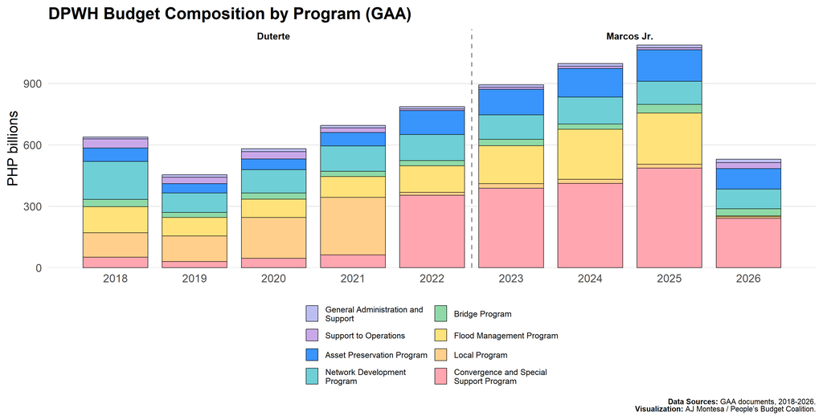

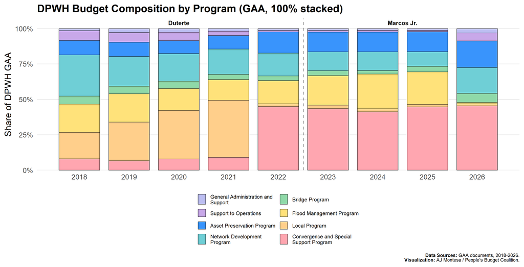

GAA by Program, PHP billions

| Program | 2026 | 2025 | 2024 | 2023 | 2022 | 2021 | 2020 | 2019 | 2018 |
| --- | --- | --- | --- | --- | --- | --- | --- | --- | --- |
| General Administration and Support | 16.6 | 13.3 | 12.8 | 12.6 | 10.4 | 12.8 | 15.0 | 12.6 | 9.5 |
| Support to Operations | 29.6 | 10.3 | 11.7 | 9.8 | 8.3 | 21.6 | 34.8 | 31.5 | 44.5 |
| Asset Preservation Program | 99.4 | 154.1 | 139.0 | 124.6 | 117.5 | 66.0 | 52.9 | 45.5 | 65.0 |
| Network Development Program | 96.8 | 112.7 | 132.3 | 119.2 | 127.0 | 124.5 | 113.4 | 95.3 | 185.5 |
| Bridge Program | 34.1 | 42.6 | 24.8 | 31.2 | 25.4 | 25.4 | 30.2 | 24.3 | 35.7 |
| Flood Management Program | 4.8 | 249.8 | 244.6 | 185.8 | 129.0 | 101.8 | 90.1 | 90.7 | 127.7 |
| Local Program | 7.8 | 18.7 | 20.6 | 21.7 | 15.4 | 280.6 | 198.8 | 123.9 | 119.0 |
| Convergence and Special Support Program | 240.5 | 486.2 | 411.0 | 388.3 | 352.8 | 62.1 | 45.7 | 30.3 | 51.0 |

## 6.2 NEP vs GAA and Realignments

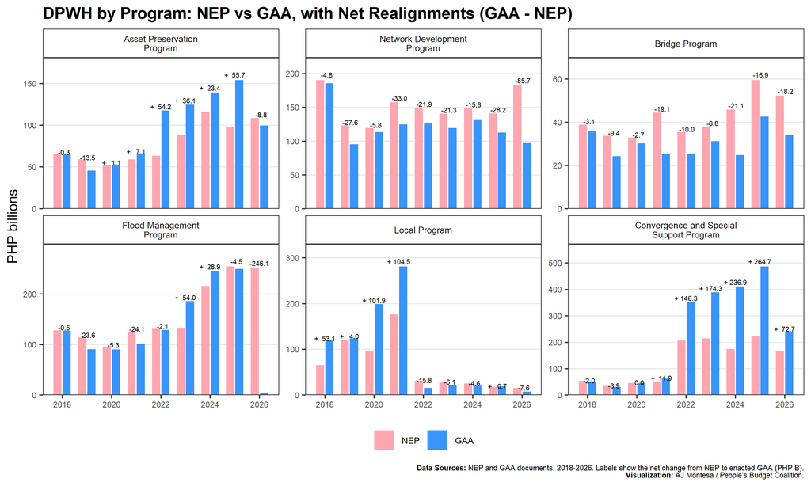

The same realignments read most cleanly as a matrix — each cell is the net move from the President’s proposal (NEP) to the enacted law (GAA), with **blue = increases** and **red = cuts**:

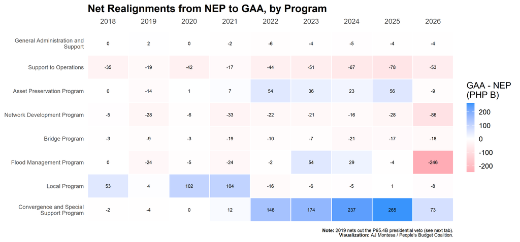

Net Realignment (GAA - NEP) by Program, PHP billions

| Program | 2026 | 2025 | 2024 | 2023 | 2022 | 2021 | 2020 | 2019 | 2018 |
| --- | --- | --- | --- | --- | --- | --- | --- | --- | --- |
| General Administration and Support | -3.9 | -4.3 | -4.6 | -3.5 | -6.0 | -2.4 | 0.0 | 2.1 | 0.1 |
| Support to Operations | -52.8 | -78.4 | -67.5 | -50.9 | -44.1 | -16.6 | -41.7 | -18.5 | -34.9 |
| Asset Preservation Program | -8.8 | 55.7 | 23.4 | 36.1 | 54.2 | 7.1 | 1.1 | -13.5 | -0.3 |
| Network Development Program | -85.7 | -28.2 | -15.8 | -21.3 | -21.9 | -33.0 | -5.8 | -27.6 | -4.8 |
| Bridge Program | -18.2 | -16.9 | -21.1 | -6.8 | -10.0 | -19.1 | -2.7 | -9.4 | -3.1 |
| Flood Management Program | -246.1 | -4.5 | 28.9 | 54.0 | -2.1 | -24.1 | -5.3 | -23.6 | -0.5 |
| Local Program | -7.6 | 0.7 | -4.6 | -6.1 | -15.8 | 104.5 | 101.9 | 4.0 | 53.1 |
| Convergence and Special Support Program | 72.7 | 264.7 | 236.9 | 174.3 | 146.3 | 11.9 | 0.0 | -3.9 | -2.0 |

## 6.3 The 2019 Line-Item Veto

In FY2019, Congress raised the DPWH’s New Appropriations only modestly in aggregate (from a **₱544.5B** proposal to a **₱549.4B** legislated total) but **heavily reallocated** the money — above all into the Local Program. The President then exercised **line-item vetoes worth ₱95.37B**, almost all of it from that program, bringing the enacted GAA down to **₱454.0B** (the NEP-to-GAA dip visible back in Section 1). The three stages below are what the President **proposed** (NEP), what Congress **legislated** (the pre-veto total), and what was finally **enacted** after the line-item veto.

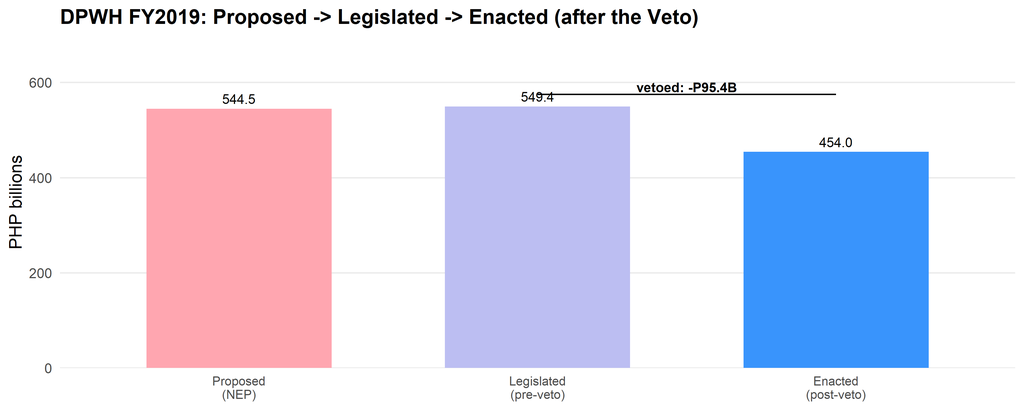

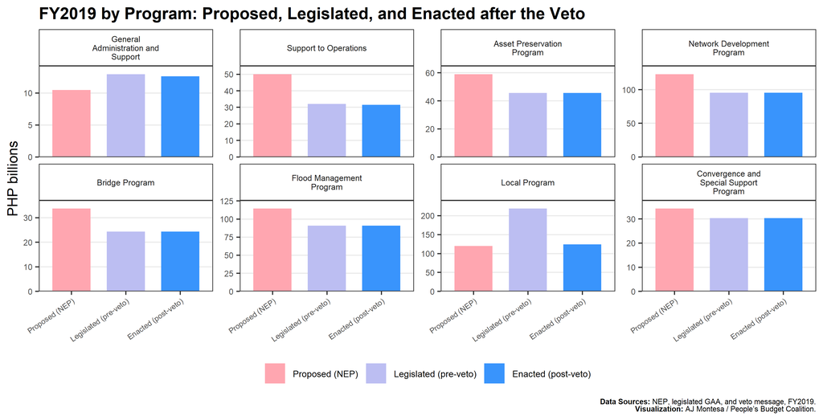

The veto was overwhelmingly a **Local Program** event: only that program (plus token amounts in the two overhead lines) shows a legislated (pre-veto) bar towering over the enacted level. Unpacking the vetoed line items by **type of work** and by **engineering office** shows where the realigned money had been parked:

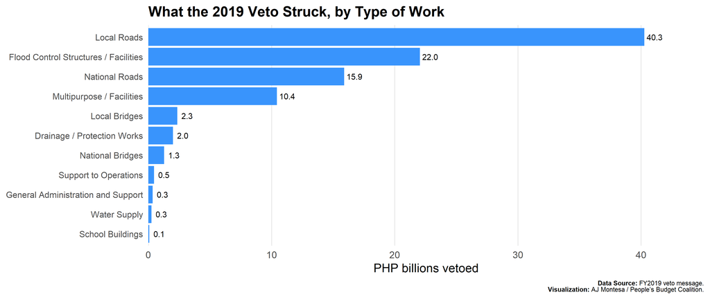

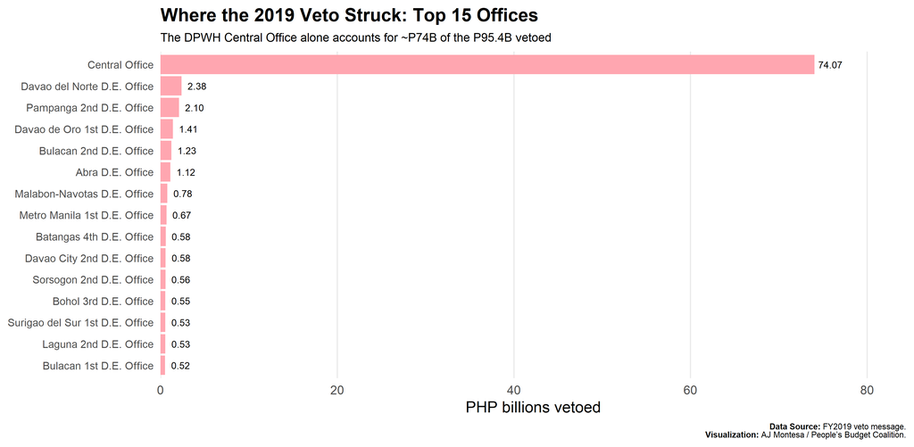

FY2019 DPWH: proposed, legislated (pre-veto), vetoed, and enacted (post-veto) — PHP billions

| Program | Proposed (NEP) | Legislated (pre-veto) | Vetoed | Enacted (post-veto) |
| --- | --- | --- | --- | --- |
| General Administration and Support | 10.5 | 12.9 | 0.3 | 12.6 |
| Support to Operations | 50.0 | 31.9 | 0.5 | 31.5 |
| Asset Preservation Program | 59.0 | 45.5 | 0.0 | 45.5 |
| Network Development Program | 122.9 | 95.3 | 0.0 | 95.3 |
| Bridge Program | 33.7 | 24.3 | 0.0 | 24.3 |
| Flood Management Program | 114.3 | 90.7 | 0.0 | 90.7 |
| Local Program | 119.9 | 218.4 | 94.6 | 123.9 |
| Convergence and Special Support Program | 34.3 | 30.3 | 0.0 | 30.3 |
| DPWH TOTAL | 544.5 | 549.4 | 95.4 | 454.0 |

FY2019 vetoed line items, by type of work

| Activity | Vetoed (PHP B) | Share of veto |
| --- | --- | --- |
| Local Roads | 40.27 | 42.2% |
| Flood Control Structures / Facilities | 22.05 | 23.1% |
| National Roads | 15.89 | 16.7% |
| Multipurpose / Facilities | 10.43 | 10.9% |
| Local Bridges | 2.34 | 2.5% |
| Drainage / Protection Works | 1.99 | 2.1% |
| National Bridges | 1.27 | 1.3% |
| Support to Operations | 0.46 | 0.5% |
| General Administration and Support | 0.35 | 0.4% |
| Water Supply | 0.25 | 0.3% |
| School Buildings | 0.08 | 0.1% |

# 7 DPWH and the Unprogrammed Appropriations

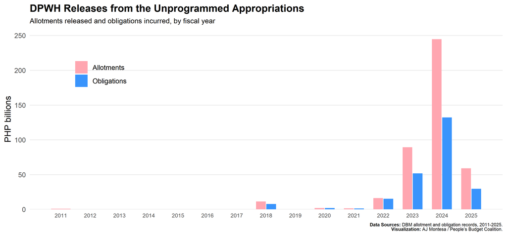

After a decade of negligible draws, UA releases to the DPWH surged from **₱16B in 2022 to ₱89B in 2023 and ₱245B in 2024** — the latter alone roughly a quarter of the department’s entire regular budget that year. Yet a large share of these allotments went unobligated (about **54% utilised in 2024**, **50% in 2025**), which — alongside the project-level findings reported elsewhere — is exactly the kind of pattern that merits questioning at the hearings.

DPWH releases from the Unprogrammed Appropriations, PHP billions

| FY | Allotments (B) | Obligations (B) | Utilization |
| --- | --- | --- | --- |
| 2011 | 0.81 | – | – |
| 2012 | 0.02 | – | – |
| 2013 | 0.00 | 0.00 | – |
| 2014 | 0.04 | 0.04 | 99% |
| 2015 | 0.00 | 0.00 | – |
| 2016 | 0.00 | 0.00 | – |
| 2017 | 0.00 | 0.00 | – |
| 2018 | 11.45 | 7.63 | 67% |
| 2019 | 0.01 | 0.01 | 100% |
| 2020 | 1.84 | 1.80 | 97% |
| 2021 | 1.36 | 1.31 | 96% |
| 2022 | 16.26 | 15.11 | 93% |
| 2023 | 89.33 | 51.72 | 58% |
| 2024 | 244.74 | 132.19 | 54% |
| 2025 | 59.08 | 29.62 | 50% |

# 8 New Appropriations by Operating Unit

The DPWH disburses its budget across some 200+ **operating units** — the Central Office, regional offices, and district engineering offices (DEOs). The data run from the **FY2020 budget** (the first of the **18th Congress**, under President Duterte) through the **19th Congress** (FY2023-2025, under President Marcos Jr.) and the opening **FY2026** budget of the 20th. That span is what lets us compare how district money moved across the two completed Congresses. Amounts are in **pesos**, rescaled to **PHP billions**.

## 8.1 Most of the Money Sits in the Central Office

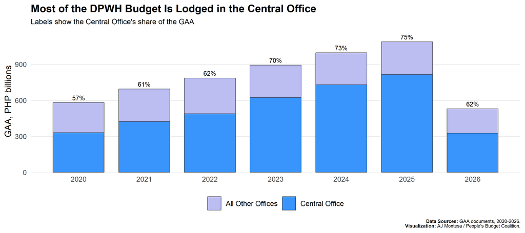

The Central Office’s hold on the budget *tightened* over the period — from **57% of the GAA in 2020 to 75% in 2025** — before the unusual 2026 GAA pulled it back to 62%. A high central share matters for oversight: money held centrally is harder to trace to specific projects and localities than money lodged in named district offices.

DPWH GAA: Central Office vs all other operating units, PHP billions

| FY | Central Office (B) | All Other Offices (B) | Total (B) | Central share |
| --- | --- | --- | --- | --- |
| 2020 | 330.1 | 250.8 | 580.9 | 56.8% |
| 2021 | 422.6 | 272.2 | 694.8 | 60.8% |
| 2022 | 487.6 | 298.1 | 785.7 | 62.1% |
| 2023 | 622.5 | 270.6 | 893.1 | 69.7% |
| 2024 | 729.1 | 267.7 | 996.8 | 73.1% |
| 2025 | 814.7 | 273.0 | 1,087.7 | 74.9% |
| 2026 | 326.6 | 203.0 | 529.6 | 61.7% |

## 8.2 Top District Offices, by Size and by Realignment

Setting the Central Office aside, two questions matter for the hearings: which district offices command the **largest budgets**, and how much of each budget was in the President’s proposal versus added on enactment. The first two charts break the largest offices into what was **proposed** (grey) and what was **added** by Congress — first in total, then split between the two Congresses that did the adding. The third chart ranks offices by the realignments they received within each Congress, coloured by the fiscal year that delivered them.

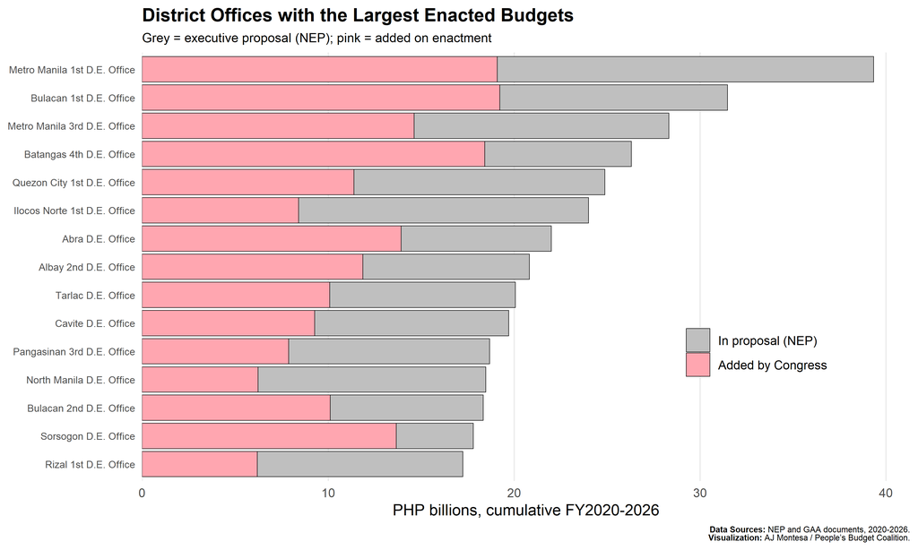

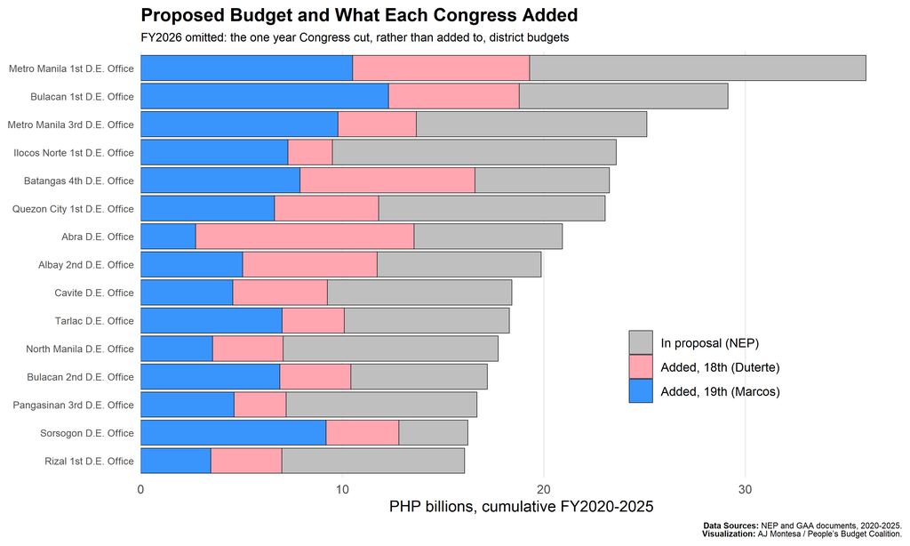

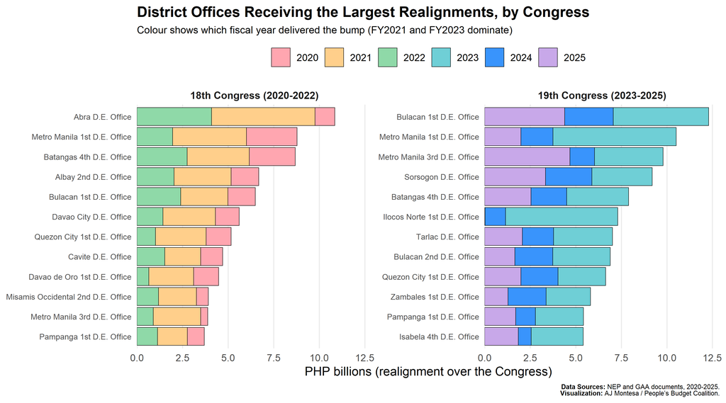

The realignment matrix below adds the year-by-year timing for the most-favoured offices — making clear, for instance, that **Abra**’s windfalls were concentrated in the Duterte-era budgets (2020-2022), while others peak later.

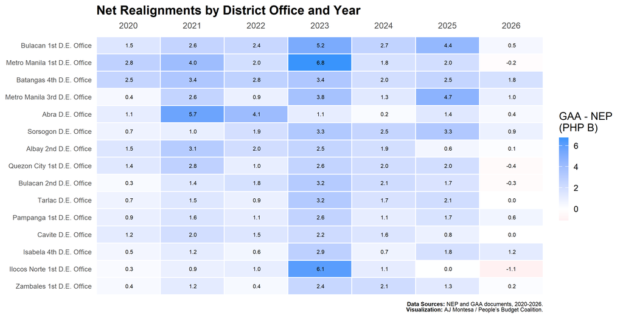

Top 20 D.E. Offices by total NEP-to-GAA realignment, FY2020-2025 (PHP billions)

| Office | 18th (Duterte) | 19th (Marcos) | Total (B) |
| --- | --- | --- | --- |
| Metro Manila 1st D.E. Office | 8.8 | 10.5 | 19.3 |
| Bulacan 1st D.E. Office | 6.5 | 12.3 | 18.8 |
| Batangas 4th D.E. Office | 8.7 | 7.9 | 16.6 |
| Metro Manila 3rd D.E. Office | 3.9 | 9.8 | 13.7 |
| Abra D.E. Office | 10.9 | 2.7 | 13.6 |
| Sorsogon D.E. Office | 3.6 | 9.2 | 12.8 |
| Quezon City 1st D.E. Office | 5.2 | 6.6 | 11.8 |
| Albay 2nd D.E. Office | 6.7 | 5.0 | 11.7 |
| Bulacan 2nd D.E. Office | 3.5 | 6.9 | 10.4 |
| Tarlac D.E. Office | 3.1 | 7.0 | 10.1 |
| Ilocos Norte 1st D.E. Office | 2.2 | 7.3 | 9.5 |
| Cavite D.E. Office | 4.7 | 4.6 | 9.3 |
| Pampanga 1st D.E. Office | 3.7 | 5.4 | 9.1 |
| Zambales 1st D.E. Office | 2.0 | 5.8 | 7.8 |
| Isabela 4th D.E. Office | 2.3 | 5.4 | 7.7 |
| Davao City D.E. Office | 5.6 | 2.1 | 7.7 |
| Laguna 2nd D.E. Office | 3.0 | 4.3 | 7.4 |
| Pangasinan 3rd D.E. Office | 2.6 | 4.6 | 7.2 |
| North Manila D.E. Office | 3.5 | 3.6 | 7.1 |
| Rizal 1st D.E. Office | 3.5 | 3.5 | 7.0 |

## 8.3 Which District Offices Merit a Closer Look?

Rather than single out any one region, this section applies a transparent screen to *every* district office and lets the data nominate which ones deserve a deeper dive. Each office is scored on four independent signals over FY2020-2026:

- **Size** — it is among the ten largest recipients of realignments;
- **Intensity** — realignments make up at least 60% of the office’s enacted budget;
- **Persistence** — it received a realignment in at least six of the seven years;
- **Tilt** — one administration favoured it over the other by at least ₱4B.

Offices that trip several signals at once are the natural candidates for scrutiny.

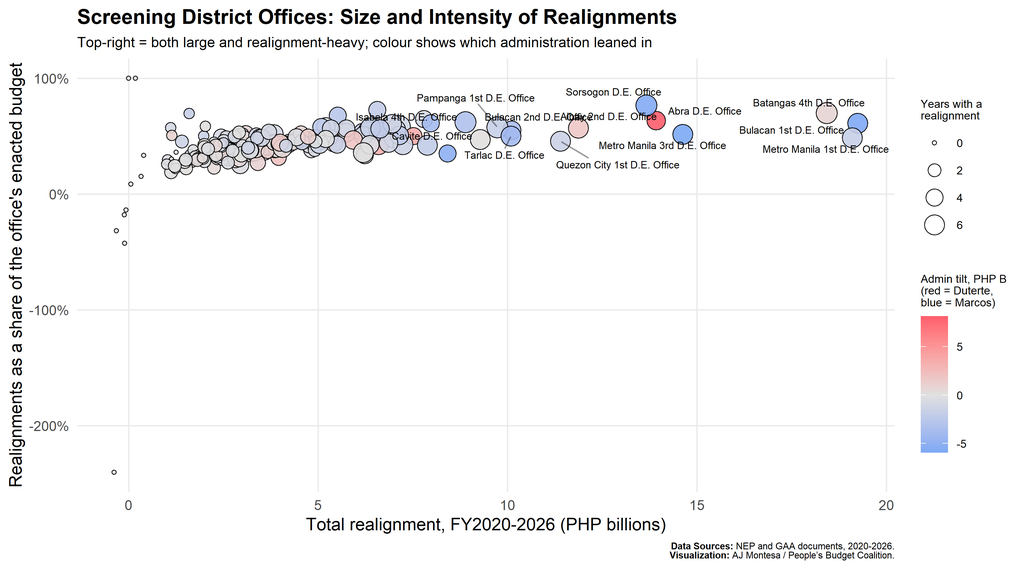

The screen returns a consistent shortlist — none of it about a single region. **Sorsogon D.E. Office** is the most realignment-dependent of the large offices: **77% of its enacted budget** (₱13.7B) was added by Congress, in every one of the seven years, and increasingly under the Marcos-era budgets. **Batangas 4th** is similar (70%, all seven years, ₱18.4B) but favoured roughly equally by both administrations — a standing fixture regardless of who is in power. **Bulacan 1st** is the single largest recipient (₱19.2B) and still climbing, with ₱7.1B realigned in 2024-2025 alone. At the politically lopsided extremes sit **Abra** — the clearest Duterte-era office (₱10.9B vs ₱2.7B) — and **Metro Manila 3rd**, its Marcos-era mirror. These offices, not any one province, are where the strongest patterns lie and where project-level records would be worth pulling.

District offices flagged for a closer look, sorted by number of signals then size

| Office | Realignment (B) | Realignment share | Years realigned | Duterte (B) | Marcos (B) | Flags | Signals |
| --- | --- | --- | --- | --- | --- | --- | --- |
| Bulacan 1st D.E. Office | 19.2 | 61% | 6/7 | 6.5 | 12.3 | 4 | large; realignment-heavy; every year; Marcos-leaning |
| Sorsogon D.E. Office | 13.7 | 77% | 7/7 | 3.6 | 9.2 | 4 | large; realignment-heavy; every year; Marcos-leaning |
| Batangas 4th D.E. Office | 18.4 | 70% | 7/7 | 8.7 | 7.9 | 3 | large; realignment-heavy; every year |
| Metro Manila 3rd D.E. Office | 14.6 | 52% | 6/7 | 3.9 | 9.8 | 3 | large; every year; Marcos-leaning |
| Abra D.E. Office | 13.9 | 63% | 5/7 | 10.9 | 2.7 | 3 | large; realignment-heavy; Duterte-leaning |
| Metro Manila 1st D.E. Office | 19.1 | 49% | 6/7 | 8.8 | 10.5 | 2 | large; every year |
| Albay 2nd D.E. Office | 11.9 | 57% | 6/7 | 6.7 | 5.0 | 2 | large; every year |
| Quezon City 1st D.E. Office | 11.4 | 46% | 6/7 | 5.2 | 6.6 | 2 | large; every year |
| Tarlac D.E. Office | 10.1 | 50% | 6/7 | 3.1 | 7.0 | 2 | large; every year |
| Isabela 4th D.E. Office | 8.9 | 62% | 7/7 | 2.3 | 5.4 | 2 | realignment-heavy; every year |
| Bulacan 2nd D.E. Office | 10.1 | 55% | 5/7 | 3.5 | 6.9 | 1 | large |
| Pampanga 1st D.E. Office | 9.7 | 58% | 7/7 | 3.7 | 5.4 | 1 | every year |
| Cavite D.E. Office | 9.3 | 47% | 6/7 | 4.7 | 4.6 | 1 | every year |
| Ilocos Norte 1st D.E. Office | 8.4 | 35% | 4/7 | 2.2 | 7.3 | 1 | Marcos-leaning |
| Zambales 1st D.E. Office | 8.0 | 61% | 4/7 | 2.0 | 5.8 | 1 | realignment-heavy |

# 9 Notes

> **On coverage.** The Section 1 series is intentionally left with gaps where the physical documents have not yet been encoded; points mark observed years. The by-operating-unit data begins with the FY2020 budget, so administration-level comparisons reach back to the 18th Congress (Duterte) but no further for now. As more years are filled in, every plot and table updates on re-knit.

> **On the 2019 GAA.** The GAA figures throughout are the **enacted, post-veto** levels (they reconcile to the Office-of-the-Secretary totals in Section 1). “Legislated (pre-veto)” reconstructs what Congress passed by adding the vetoed amounts back to the enacted GAA. Because of this, the 2019 column of the realignment matrix reflects congressional reallocation *net of* the veto; the veto section isolates the veto itself.